# David Smyth - Udacity - Intro to Data Analysis - Investigate a Dataset Project-Resubmittal-Copy2

David Smyth - Udacity - Intro to Data Analysis - Investigate a Dataset Project

Utilizing the The Lahman Baseball Database of Major League Baseball statistics from 1871 through 2016, this data analysis seeks to determine the effects of the Live-ball and Steroid eras on player offensive performance.

American professional baseball can be divided into three eras, the Dead-ball era, the Live-ball era and the Steroid era. During the Dead-ball era, which ended in 1920, pitchers were favored by the re-utilization of a single baseball throughout the game. This era was followed by the Live-ball era in which baseballs were replaced durimg the game at the first sign of wear resulting in increased offensive performance. The steroid era also saw increased offensive production.

Statistically, what could be said to be the effect of these subsequent eras upon player offensive performance? Furthermore, given the said enhancement of player offensive performance, what player, in retrospect, could be said to be the true home run king.

# Loading Data from the CSV

```python
#Reading in the .csv file into a dataframe.

import pandas as pd
batting_df = pd.read_csv('Batting.csv')
print batting_df
```

```
         playerID  yearID  stint teamID lgID    G   AB   R    H  2B  ...   \
0       abercda01    1871      1    TRO  NaN    1    4   0    0   0  ...
1        addybo01    1871      1    RC1  NaN   25  118  30   32   6  ...
2       allisar01    1871      1    CL1  NaN   29  137  28   40   4  ...
3       allisdo01    1871      1    WS3  NaN   27  133  28   44  10  ...
4       ansonca01    1871      1    RC1  NaN   25  120  29   39  11  ...
5       armstbo01    1871      1    FW1  NaN   12   49   9   11   2  ...
6       barkeal01    1871      1    RC1  NaN    1    4   0    1   0  ...
7       barnero01    1871      1    BS1  NaN   31  157  66   63  10  ...
8       barrebi01    1871      1    FW1  NaN    1    5   1    1   1  ...
9       barrofr01    1871      1    BS1  NaN   18   86  13   13   2  ...
10       bassjo01    1871      1    CL1  NaN   22   89  18   27   1  ...
11      battijo01    1871      1    CL1  NaN    1    3   0    0   0  ...
12      bealsto01    1871      1    WS3  NaN   10   36   6    7   0  ...
13      beaveed01    1871      1    TRO  NaN    3   15   7    6   0  ...
```

[output cut: 112 more lines]

# Investigating the Data

```python
#Displaying the column ID's

batting_df.columns
```

```
Index([u'playerID', u'yearID', u'stint', u'teamID', u'lgID', u'G', u'AB', u'R',
       u'H', u'2B', u'3B', u'HR', u'RBI', u'SB', u'CS', u'BB', u'SO', u'IBB',
       u'HBP', u'SH', u'SF', u'GIDP'],
      dtype='object')
```

# Data Wrangling

```python
#This code returns null or NaN values in the data

batting_df.isnull().sum()
```

```
playerID        0
yearID          0
stint           0
teamID          0
lgID          737
G               0
AB              0
R               0
H               0
2B              0
3B              0
HR              0
RBI           424
SB           1300
CS          23456
BB              0
SO           7838
IBB         36565
HBP          2810
SH           6338
SF          36034
GIDP        26110
dtype: int64
```

The columns we are concerned with are playerID, yearID and HR which show no null values in the dataset so no further cleaning of the dataset is required.

# Grouping by era

```python
# Using grouby to seperate out the different eras as indicated by YearID

dbe_df = batting_df.groupby('yearID').filter(lambda x: (x['yearID'] < 1920).any())
```

```python
lbe_df = batting_df.groupby('yearID').filter(lambda x: (x['yearID'] >= 1920).any())
lbe_df = lbe_df.groupby('yearID').filter(lambda x: (x['yearID'] <= 1992).any())
```

```python
se_df = batting_df.groupby('yearID').filter(lambda x: (x['yearID'] >= 1993).any())
se_df = se_df.groupby('yearID').filter(lambda x: (x['yearID'] <= 2002).any())
```

## The Dead-ball era

```python
print dbe_df
```

```
        playerID  yearID  stint teamID lgID    G   AB   R    H  2B  ...   \
0      abercda01    1871      1    TRO  NaN    1    4   0    0   0  ...
1       addybo01    1871      1    RC1  NaN   25  118  30   32   6  ...
2      allisar01    1871      1    CL1  NaN   29  137  28   40   4  ...
3      allisdo01    1871      1    WS3  NaN   27  133  28   44  10  ...
4      ansonca01    1871      1    RC1  NaN   25  120  29   39  11  ...
5      armstbo01    1871      1    FW1  NaN   12   49   9   11   2  ...
6      barkeal01    1871      1    RC1  NaN    1    4   0    1   0  ...
7      barnero01    1871      1    BS1  NaN   31  157  66   63  10  ...
8      barrebi01    1871      1    FW1  NaN    1    5   1    1   1  ...
9      barrofr01    1871      1    BS1  NaN   18   86  13   13   2  ...
10      bassjo01    1871      1    CL1  NaN   22   89  18   27   1  ...
11     battijo01    1871      1    CL1  NaN    1    3   0    0   0  ...
12     bealsto01    1871      1    WS3  NaN   10   36   6    7   0  ...
13     beaveed01    1871      1    TRO  NaN    3   15   7    6   0  ...
```

[output cut: 112 more lines]

```python
dbe_df.describe()
```

|  | yearID | stint | G | AB | R | H | 2B | 3B | HR | RBI | SB | CS | BB | SO | IBB | HBP | SH | SF | GIDP |
| --- | --- | --- | --- | --- | --- | --- | --- | --- | --- | --- | --- | --- | --- | --- | --- | --- | --- | --- | --- |
| count | 18138.000000 | 18138.000000 | 18138.000000 | 18138.000000 | 18138.000000 | 18138.000000 | 18138.000000 | 18138.000000 | 18138.000000 | 17714.000000 | 16838.000000 | 1418.000000 | 18138.000000 | 10300.000000 | 213.0 | 15328.000000 | 11800.000000 | 196.0 | 192.0 |
| mean | 1900.484783 | 1.085842 | 48.372423 | 169.507388 | 23.748925 | 43.922979 | 6.235969 | 2.520123 | 0.910409 | 18.745851 | 6.728353 | 3.528209 | 13.084464 | 15.340388 | 0.0 | 1.696242 | 5.045678 | 0.0 | 0.0 |
| std | 13.058476 | 0.306096 | 46.488958 | 180.205428 | 30.553802 | 51.949746 | 8.329767 | 3.894889 | 2.034648 | 24.569870 | 12.274027 | 6.116568 | 18.805696 | 16.535053 | 0.0 | 3.011165 | 7.073994 | 0.0 | 0.0 |
| min | 1871.000000 | 1.000000 | 1.000000 | 0.000000 | 0.000000 | 0.000000 | 0.000000 | 0.000000 | 0.000000 | 0.000000 | 0.000000 | 0.000000 | 0.000000 | 0.000000 | 0.0 | 0.000000 | 0.000000 | 0.0 | 0.0 |
| 25% | 1890.000000 | 1.000000 | 8.000000 | 19.000000 | 1.000000 | 3.000000 | 0.000000 | 0.000000 | 0.000000 | 1.000000 | 0.000000 | 0.000000 | 1.000000 | 2.000000 | 0.0 | 0.000000 | 0.000000 | 0.0 | 0.0 |
| 50% | 1903.000000 | 1.000000 | 33.000000 | 91.000000 | 9.000000 | 19.000000 | 2.000000 | 1.000000 | 0.000000 | 7.000000 | 1.000000 | 1.000000 | 5.000000 | 10.000000 | 0.0 | 0.000000 | 2.000000 | 0.0 | 0.0 |
| 75% | 1912.000000 | 1.000000 | 80.000000 | 287.000000 | 38.000000 | 74.000000 | 10.000000 | 4.000000 | 1.000000 | 29.000000 | 8.000000 | 4.000000 | 18.000000 | 23.000000 | 0.0 | 2.000000 | 7.000000 | 0.0 | 0.0 |
| max | 1919.000000 | 5.000000 | 162.000000 | 660.000000 | 192.000000 | 248.000000 | 55.000000 | 36.000000 | 29.000000 | 166.000000 | 138.000000 | 38.000000 | 147.000000 | 120.000000 | 0.0 | 51.000000 | 67.000000 | 0.0 | 0.0 |

Displaying statistics of the Dead-ball era. The record is indicated by max row under HR column, the mean is indicated by mean under the HR column.

## The Live-ball era

```python
print lbe_df
```

```
        playerID  yearID  stint teamID lgID    G   AB   R    H  2B  ...   \
18138  acostjo01    1920      1    WS1   AL   17   25   2    6   1  ...
18139  adamsba01    1920      1    PIT   NL   35   89   4   13   0  ...
18140  ainsmed01    1920      1    DET   AL   69  186  19   43   5  ...
18141  alexape01    1920      1    CHN   NL   46  118   9   27   4  ...
18142  allenni01    1920      1    CIN   NL   43   85  10   23   3  ...
18143  altener01    1920      1    DET   AL   14    3   0    0   0  ...
18144  austiji01    1920      1    SLA   AL   83  280  38   76  11  ...
18145  ayersdo01    1920      1    DET   AL   46   59   2    9   4  ...
18146  bagbyji01    1920      1    CLE   AL   49  131  17   33   7  ...
18147  bailege01    1920      1    BSN   NL   13   24   2    2   0  ...
18148  bailege01    1920      2    BOS   AL   46  135  14   31   2  ...
18149  bailesw01    1920      1    CHN   NL   21    7   0    1   0  ...
18150  bairddo01    1920      1    BRO   NL    6    6   1    2   0  ...
18151  bairddo01    1920      2    NY1   NL    7    8   0    1   0  ...
```

[output cut: 112 more lines]

```python
lbe_df.describe()
```

|  | yearID | stint | G | AB | R | H | 2B | 3B | HR | RBI | SB | CS | BB | SO | IBB | HBP | SH | SF | GIDP |
| --- | --- | --- | --- | --- | --- | --- | --- | --- | --- | --- | --- | --- | --- | --- | --- | --- | --- | --- | --- |
| count | 52539.000000 | 52539.000000 | 52539.000000 | 52539.000000 | 52539.000000 | 52539.000000 | 52539.000000 | 52539.000000 | 52539.000000 | 52539.000000 | 52539.000000 | 45803.000000 | 52539.000000 | 52539.000000 | 33899.000000 | 52539.000000 | 52539.000000 | 34447.000000 | 44375.000000 |
| mean | 1961.404442 | 1.070005 | 53.219799 | 145.397686 | 18.623613 | 38.124517 | 6.334532 | 1.253412 | 2.960582 | 17.317574 | 2.270180 | 1.379538 | 13.966729 | 19.481947 | 1.310511 | 0.794096 | 2.389482 | 1.117427 | 3.174287 |
| std | 21.045070 | 0.269241 | 48.183044 | 187.655995 | 27.839495 | 53.737882 | 9.626433 | 2.486486 | 6.317701 | 26.638950 | 6.253304 | 2.910691 | 21.554013 | 25.168434 | 2.906297 | 1.713037 | 3.987430 | 2.000319 | 4.762432 |
| min | 1920.000000 | 1.000000 | 1.000000 | 0.000000 | 0.000000 | 0.000000 | 0.000000 | 0.000000 | 0.000000 | 0.000000 | 0.000000 | 0.000000 | 0.000000 | 0.000000 | 0.000000 | 0.000000 | 0.000000 | 0.000000 | 0.000000 |
| 25% | 1944.000000 | 1.000000 | 14.000000 | 6.000000 | 0.000000 | 1.000000 | 0.000000 | 0.000000 | 0.000000 | 0.000000 | 0.000000 | 0.000000 | 0.000000 | 1.000000 | 0.000000 | 0.000000 | 0.000000 | 0.000000 | 0.000000 |
| 50% | 1965.000000 | 1.000000 | 36.000000 | 52.000000 | 4.000000 | 9.000000 | 1.000000 | 0.000000 | 0.000000 | 4.000000 | 0.000000 | 0.000000 | 3.000000 | 9.000000 | 0.000000 | 0.000000 | 1.000000 | 0.000000 | 1.000000 |
| 75% | 1980.000000 | 1.000000 | 86.000000 | 235.000000 | 27.000000 | 59.000000 | 9.000000 | 1.000000 | 3.000000 | 25.000000 | 2.000000 | 1.000000 | 20.000000 | 28.000000 | 1.000000 | 1.000000 | 3.000000 | 1.000000 | 5.000000 |
| max | 1992.000000 | 4.000000 | 165.000000 | 705.000000 | 177.000000 | 257.000000 | 67.000000 | 26.000000 | 61.000000 | 191.000000 | 130.000000 | 42.000000 | 170.000000 | 189.000000 | 45.000000 | 50.000000 | 48.000000 | 19.000000 | 36.000000 |

Displaying statistics of the Live-ball era. The record is indicated by max row under HR column, the mean is indicated by mean under the HR column.

## The Steroid era

```python
print se_df
```

```
        playerID  yearID  stint teamID lgID    G   AB    R    H  2B  ...   \
70677  abbotji01    1993      1    NYA   AL   32    0    0    0   0  ...
70678  abbotku01    1993      1    OAK   AL   20   61   11   15   1  ...
70679  abbotpa01    1993      1    CLE   AL    5    0    0    0   0  ...
70680  agostju01    1993      1    HOU   NL    6    0    0    0   0  ...
70681  aguilri01    1993      1    MIN   AL   65    0    0    0   0  ...
70682  aldremi01    1993      1    OAK   AL   95  255   40   68  13  ...
70683  aldresc01    1993      1    COL   NL    5    0    0    0   0  ...
70684  aldresc01    1993      2    MON   NL    3    0    0    0   0  ...
70685  alexama02    1993      1    BAL   AL    3    0    1    0   0  ...
70686  alicelu01    1993      1    SLN   NL  115  362   50  101  19  ...
70687  allanan01    1993      1    SFN   NL   13   24    3    4   1  ...
70688  alomaro01    1993      1    TOR   AL  153  589  109  192  35  ...
70689  alomasa02    1993      1    CLE   AL   64  215   24   58   7  ...
70690   aloumo01    1993      1    MON   NL  136  482   70  138  29  ...
```

[output cut: 112 more lines]

```python
se_df.describe()
```

|  | yearID | stint | G | AB | R | H | 2B | 3B | HR | RBI | SB | CS | BB | SO | IBB | HBP | SH | SF | GIDP |
| --- | --- | --- | --- | --- | --- | --- | --- | --- | --- | --- | --- | --- | --- | --- | --- | --- | --- | --- | --- |
| count | 12615.000000 | 12615.000000 | 12615.000000 | 12615.000000 | 12615.000000 | 12615.000000 | 12615.000000 | 12615.000000 | 12615.000000 | 12615.000000 | 12615.000000 | 12615.000000 | 12615.000000 | 12615.000000 | 12615.000000 | 12615.000000 | 12615.000000 | 12615.000000 | 12615.000000 |
| mean | 1997.670155 | 1.087753 | 50.298692 | 122.824336 | 17.373841 | 32.803012 | 6.342925 | 0.700357 | 3.790805 | 16.458423 | 2.416409 | 1.101308 | 12.434958 | 22.902259 | 0.976377 | 1.151249 | 1.252874 | 1.076576 | 2.774396 |
| std | 2.845341 | 0.296357 | 45.441813 | 178.774515 | 28.346123 | 51.043656 | 10.346075 | 1.578488 | 7.877827 | 27.983721 | 6.459909 | 2.435412 | 21.509811 | 32.727544 | 2.704062 | 2.543009 | 2.477828 | 2.046433 | 4.609690 |
| min | 1993.000000 | 1.000000 | 1.000000 | 0.000000 | 0.000000 | 0.000000 | 0.000000 | 0.000000 | 0.000000 | 0.000000 | 0.000000 | 0.000000 | 0.000000 | 0.000000 | 0.000000 | 0.000000 | 0.000000 | 0.000000 | 0.000000 |
| 25% | 1995.000000 | 1.000000 | 14.000000 | 1.000000 | 0.000000 | 0.000000 | 0.000000 | 0.000000 | 0.000000 | 0.000000 | 0.000000 | 0.000000 | 0.000000 | 0.000000 | 0.000000 | 0.000000 | 0.000000 | 0.000000 | 0.000000 |
| 50% | 1998.000000 | 1.000000 | 34.000000 | 24.000000 | 2.000000 | 4.000000 | 1.000000 | 0.000000 | 0.000000 | 2.000000 | 0.000000 | 0.000000 | 1.000000 | 6.000000 | 0.000000 | 0.000000 | 0.000000 | 0.000000 | 0.000000 |
| 75% | 2000.000000 | 1.000000 | 75.000000 | 188.000000 | 24.000000 | 47.500000 | 9.000000 | 1.000000 | 4.000000 | 22.000000 | 1.000000 | 1.000000 | 16.000000 | 33.000000 | 1.000000 | 1.000000 | 1.000000 | 1.000000 | 4.000000 |
| max | 2002.000000 | 4.000000 | 163.000000 | 696.000000 | 152.000000 | 242.000000 | 59.000000 | 21.000000 | 73.000000 | 165.000000 | 75.000000 | 24.000000 | 198.000000 | 188.000000 | 68.000000 | 34.000000 | 25.000000 | 17.000000 | 32.000000 |

Displaying statistics of the Steroid era. The record is indicated by max row under HR column, the mean is indicated by mean under the HR column.

# Plotting the Data

[figure not shown]

```python
data_by_hits_per_year = dbe_df.groupby(['yearID', 'H'], as_index=False).mean()
data_by_hits_per_year.head()['yearID']
%pylab inline

import matplotlib.pyplot as plt
import seaborn as sns
scaled_entries = (data_by_hits_per_year['HR']/ data_by_hits_per_year['HR'].std())
plt.scatter (data_by_hits_per_year['yearID'], data_by_hits_per_year['H'], s=scaled_entries)
plt.xlabel("Dead-ball era Year")
plt.ylabel("Dead-ball era HR's")
```

[figure not shown]

```python
data_by_hits_per_year = lbe_df.groupby(['yearID', 'H'], as_index=False).mean()
data_by_hits_per_year.head()['yearID']
%pylab inline

import matplotlib.pyplot as plt
import seaborn as sns
scaled_entries = (data_by_hits_per_year['HR']/ data_by_hits_per_year['HR'].std())
plt.scatter (data_by_hits_per_year['yearID'], data_by_hits_per_year['H'], s=scaled_entries)
plt.xlabel("Live-ball era Year")
plt.ylabel("Live-ball era HR's")
```

[figure not shown]

```python
data_by_hits_per_year = se_df.groupby(['yearID', 'H'], as_index=False).mean()
data_by_hits_per_year.head()['yearID']
%pylab inline

import matplotlib.pyplot as plt
import seaborn as sns
scaled_entries = (data_by_hits_per_year['HR']/ data_by_hits_per_year['HR'].std())
plt.scatter (data_by_hits_per_year['yearID'], data_by_hits_per_year['H'], s=scaled_entries)
plt.xlabel("Steroid era Year")
plt.ylabel("Steroid era HR's")
```

## Dead-ball era HR's

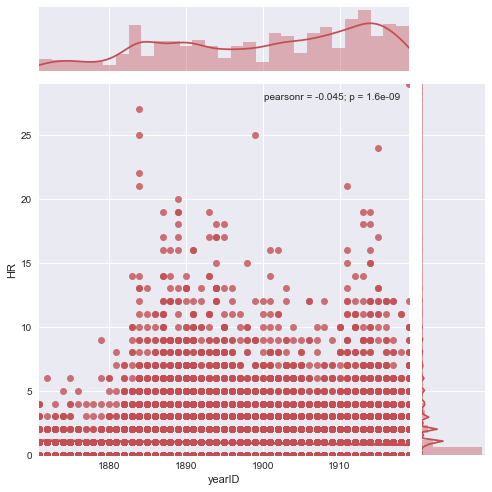

```python
import seaborn as sns
sns.set(style="darkgrid", color_codes=True)

#tips = sns.load_dataset("tips")
g = sns.jointplot("yearID", "HR", data=dbe_df, kind="reg",
                  xlim=(1871, 1919), ylim=(0, 29), color="r", size=7)
```

The joint plot above more clearly shows HR's hit during the Dead-ball era; a point higher on the y axis indicating more HR's by a player during that year as indicated by the x-axis, the record for HR's during this era is indicated in the very upper right of the graph.

## Live-ball era HR's

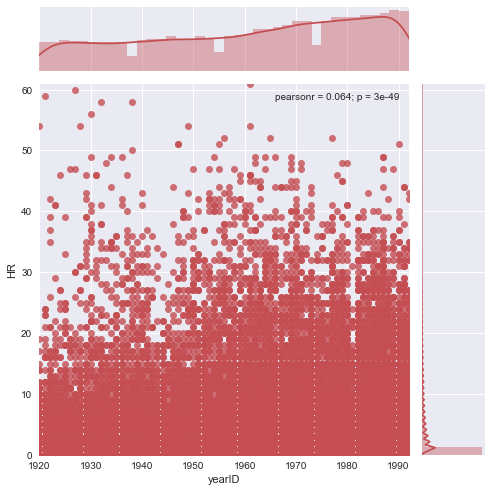

```python
import seaborn as sns
sns.set(style="darkgrid", color_codes=True)

#tips = sns.load_dataset("tips")
g = sns.jointplot("yearID", "HR", data=lbe_df, kind="reg",
                  xlim=(1920, 1992), ylim=(0, 61), color="r", size=7)
```

The joint plot above more clearly shows HR's hit during the Live-ball era; a point higher on the y axis indicating more HR's by a player during that year, the record for HR's during this era is indicated to the very right of the year 1960 as labeled on the x-axis.

## Steroid era HR's

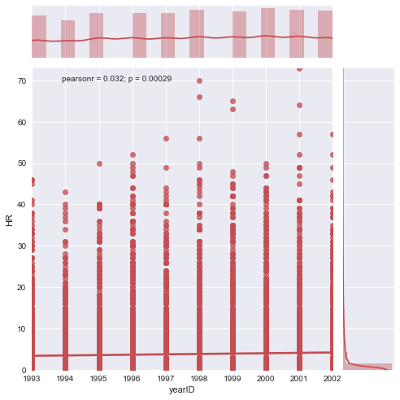

```python
import seaborn as sns
sns.set(style="darkgrid", color_codes=True)

#tips = sns.load_dataset("tips")
g = sns.jointplot("yearID", "HR", data=se_df, kind="reg",
                  xlim=(1993, 2002), ylim=(0, 73), color="r", size=7)
```

The joint plot above more clearly shows HR's hit during the Steroid era; a point higher on the y axis indicating more HR's by a player during that year, the record for HR's during this era is in the year 2001 as labeled on the x-axis.

# Sharing Findings

Computing the standard score or z-score for the steroid era's home run record shows the record, 73 home runs, is 8.79 standard deviations away from the mean for that era. Were this the standard deviation for the maximum home runs hit during the dead-ball era, the maximum home runs would have been 18.75. Instead, the maximum home runs hit during the dead-ball era was 29. Likewise, the standard deivations of 29 home runs during the dead-ball era results in a standard or z-score of 13.83. This would translate to 112.63 home runs hit during the steroid era which is 39.63 home runs more than the record! Thus controlling for ball liveliness and performance enhancement, the all-time professional baseball home run record can be said to be Babe Ruth's 29 homeruns in 1919 for the Boston Redsox. It is a greater statistical achievement than Roger Maris's 61 home runs in 1961 (live ball era) or Barry Bond's 73 home runs in 2001 (steroid era). These findings are tentative and only grossly control for era as the independent variable in the study. Further refinement of variables such as the foul-strike rule or ballpark dimensions could serve to indicate more exactly the factors by which the Live-ball and Steroid eras were most effective in increasing offensive performance.

# References

https://en.wikipedia.org/wiki/Dead-ball_era https://en.wikipedia.org/wiki/Live-ball_era https://en.wikipedia.org/wiki/Doping_in_baseball http://www.seanlahman.com/baseball-archive/statistics/